# Visualizing Models in R

Soc 505

Connor Gilroy

2020-02-20

Today, I’ll talk about working with model objects and visualizing models.

I’ll use 3 main packages:

- `broom`
- `ggplot2`
- `ggeffects`

```r
library(tidyverse)
library(haven)
library(broom)
library(ggplot2)
library(ggeffects)

# I have aesthetic opinions
theme_set(theme_minimal())
```

# Linear regression

Fit a linear model:

```r
# data from hw2
courtpenalties <- read_dta("data/courtpenalties2020_compatible.dta")

f1 <- penalties ~ minority + liberal + popsize + crt + unemp
model1 <- glm(f1, family = gaussian(), data = courtpenalties)
summary(model1)
```

```
##
## Call:
## glm(formula = f1, family = gaussian(), data = courtpenalties)
##
## Deviance Residuals:
##      Min        1Q    Median        3Q       Max
## -1747.61   -367.66     -2.94    381.70   1925.97
##
## Coefficients:
##               Estimate Std. Error t value Pr(>|t|)
## (Intercept) -9.854e+02  2.280e+02  -4.323 1.91e-05 ***
## minority     1.720e+00  6.331e-02  27.170  < 2e-16 ***
## liberal      2.759e+00  4.835e+00   0.570   0.5686
## popsize      9.081e-02  5.539e-03  16.396  < 2e-16 ***
## crt          4.954e+01  3.088e+00  16.041  < 2e-16 ***
## unemp        1.568e+01  5.797e+00   2.705   0.0071 **
## ---
## Signif. codes:  0 '***' 0.001 '**' 0.01 '*' 0.05 '.' 0.1 ' ' 1
##
## (Dispersion parameter for gaussian family taken to be 327734.6)
##
##     Null deviance: 1065767053  on 443  degrees of freedom
## Residual deviance:  143547748  on 438  degrees of freedom
## AIC: 6906.8
##
## Number of Fisher Scoring iterations: 2
```

We can extract information from the model with some generic helper functions:

```r
# coefficients (including the intercept!)
coef(model1)
```

```
##   (Intercept)      minority       liberal       popsize           crt
## -985.43312573    1.72021241    2.75857608    0.09081073   49.54217357
##         unemp
##   15.67973903
```

```r
# coefficient confidence intervals
confint(model1)
```

```
##                     2.5 %       97.5 %
## (Intercept) -1.432218e+03 -538.6479309
## minority     1.596122e+00    1.8443027
## liberal     -6.718729e+00   12.2358813
## popsize      7.995503e-02    0.1016664
## crt          4.348896e+01   55.5953847
## unemp        4.317649e+00   27.0418289
```

```r
# measures of model fit
BIC(model1)
```

```
## [1] 6935.429
```

```r
# residuals
head(residuals(model1))
```

```
##         1         2         3         4         5         6
##  871.9395 -922.7255  184.9936 -391.0747  491.3707 -436.3275
```

# Tidy model output

Is there a tidier way? Yes! That’s what `broom` is for.

Want tidy coefficients?

```r
tidy(model1)
```

```
## # A tibble: 6 x 5
##   term         estimate std.error statistic  p.value
##   <chr>           <dbl>     <dbl>     <dbl>    <dbl>
## 1 (Intercept) -985.     228.         -4.32  1.91e- 5
## 2 minority       1.72     0.0633     27.2   5.34e-96
## 3 liberal        2.76     4.84        0.570 5.69e- 1
## 4 popsize        0.0908   0.00554    16.4   1.88e-47
## 5 crt           49.5      3.09       16.0   6.91e-46
## 6 unemp         15.7      5.80        2.70  7.10e- 3
```

Want a quick summary of model fit?

```r
glance(model1)
```

```
## # A tibble: 1 x 7
##   null.deviance df.null logLik   AIC   BIC   deviance df.residual
##           <dbl>   <int>  <dbl> <dbl> <dbl>      <dbl>       <int>
## 1   1065767053.     443 -3446. 6907. 6935. 143547748.         438
```

Want fitted values and residuals?

```r
augment(model1)
```

```
## # A tibble: 444 x 13
##    penalties minority liberal popsize   crt unemp .fitted .se.fit .resid    .hat
##        <dbl>    <dbl>   <dbl>   <dbl> <dbl> <dbl>   <dbl>   <dbl>  <dbl>   <dbl>
##  1     4834.     1334    43.9   15009 19.6  12.5    3962.    73.5  872.  0.0165
##  2     3059.     1425    44.3   15647 17.5   6.75   3982.    78.5 -923.  0.0188
##  3     3122.      577    36.9   14855 24.1  18.3    2937.    83.8  185.  0.0214
##  4     2682.      307    38.7   22763 26.2   3.80   3074.    49.6 -391.  0.00749
##  5     4537.     1132    32.8   13291 33.0   9.54   4045.    73.9  491.  0.0167
##  6     3413.     1195    44.7   24951  6.29  4.99   3849.    73.7 -436.  0.0166
##  7     6764.     1324    34.9   26279 45.9  19.9    6361.    62.0  403.  0.0117
##  8     2810.      773    36.3   21350  6.00  5.92   2773.    57.0   37.2 0.00990
##  9     4946.     1455    48.7   17390 38.6  10.3    5305.    86.5 -359.  0.0228
## 10     4528.      608    41.4   25377 20.3   7.11   3597.    36.7  932.  0.00412
## # … with 434 more rows, and 3 more variables: .sigma <dbl>, .cooksd <dbl>,
## #   .std.resid <dbl>
```

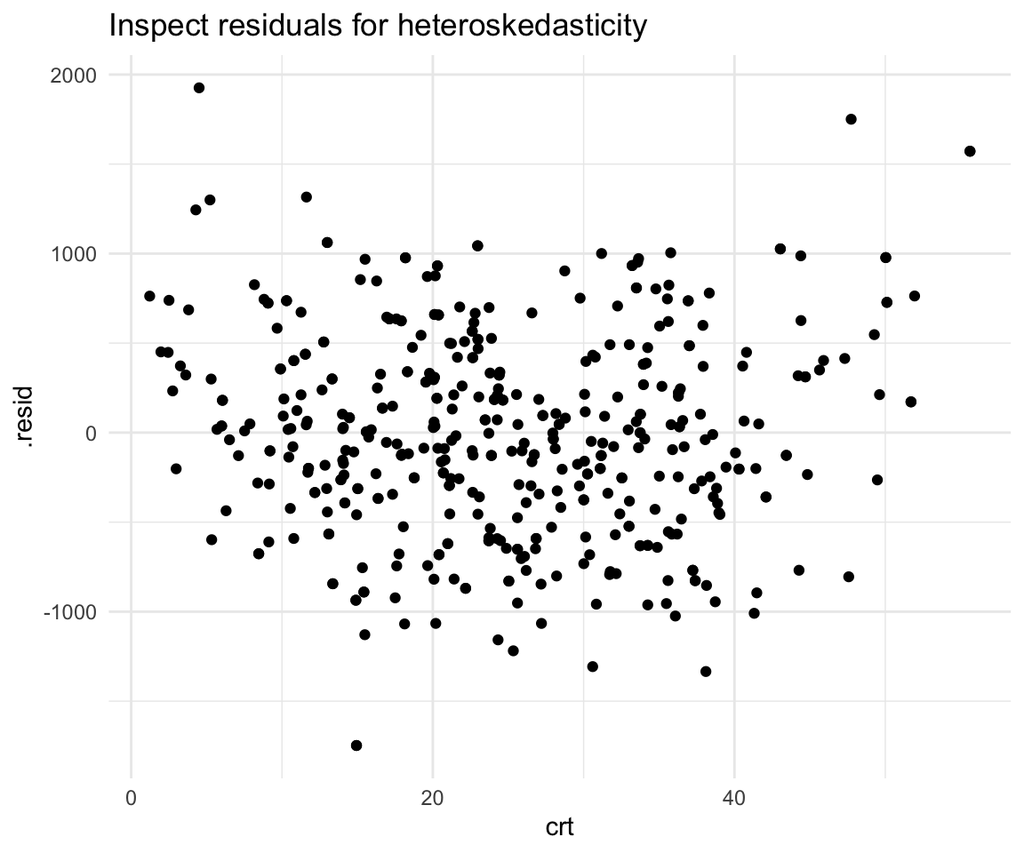

```r
augment(model1) %>%
  ggplot(aes(x = crt, y = .resid)) +
  geom_point() +
  labs(title = "Inspect residuals for heteroskedasticity")
```

# Coefficient plots

Coefficient plots are an alternative to looking at tables of coefficients.

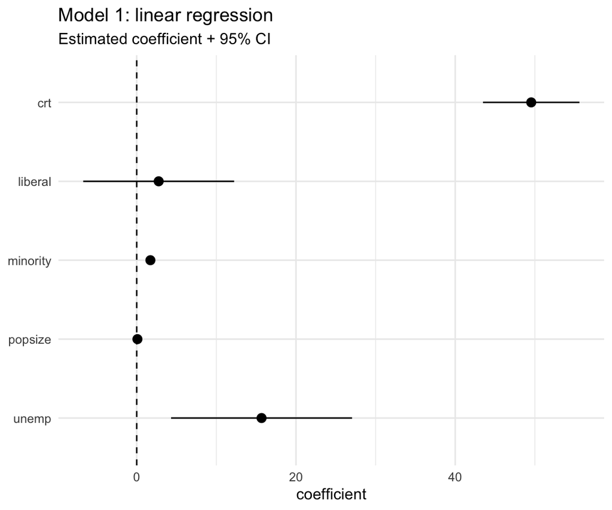

```r
model1_df <- tidy(model1, conf.int = TRUE, conf.level = .95)

model1_df %>%
  filter(term != "(Intercept)") %>%
  ggplot(aes(x = fct_rev(term), y = estimate)) +
  geom_pointrange(aes(ymin = conf.low, ymax = conf.high)) +
  geom_hline(yintercept = 0, linetype = "dashed") +
  coord_flip() +
  labs(title = "Model 1: linear regression",
       subtitle = "Estimated coefficient + 95% CI",
       x = NULL,
       y = "coefficient")
```

These aren’t standardized, so the scales are really different.

Note: `ggstance::geom_pointrangeh()` also gives a horizontal version of `geom_pointrange()`. I felt like I was already using enough packages, though…

# Marginal effects plots

Instead of plotting coefficients, we can use those coefficients to get predictions on the y scale at different x values. In particular, we can plot specific *counterfactual* values of x.

This is something we could do manually using the `predict()` function, but doing those calculations can be tricky with GLMs. (It’s relatively easy with `lm()`.)

Instead, we’ll use the `ggeffects` package. The `margins` package, which is based off of a Stata command, does something similar.

There are two ways of showing uncertainty in these plots:

- through the **confidence intervals** of the conditional means. This incorporates the uncertainty in the *systematic* part of the model—the estimates of your coefficients.
- through the **prediction intervals** of the data. This incorporates both the systematic uncertainty from the coefficients, and the uncertainty from the *stochastic* part of the model.

First, we’ll pick one covariate, `crt`. By default, `ggpredict` holds the other continuous variables constant at their mean (and categorical variables at their reference values).

```r
ggpredict(model1, terms = "crt")
```

```
##
## # Predicted values of avg $ assessed
## # x = crime rate (per 1000)
##
##   x predicted std.error conf.low conf.high
##   0  3036.884    81.396 2877.350  3196.418
##  10  3532.305    53.290 3427.859  3636.752
##  20  4027.727    31.015 3966.939  4088.515
##  30  4523.149    31.492 4461.426  4584.872
##  40  5018.571    54.122 4912.493  5124.648
##  50  5513.992    82.307 5352.674  5675.310
##  60  6009.414   111.925 5790.045  6228.783
##
## Adjusted for:
## * minority =   929.17
## *  liberal =    37.83
## *  popsize = 23770.58
## *    unemp =    10.27
```

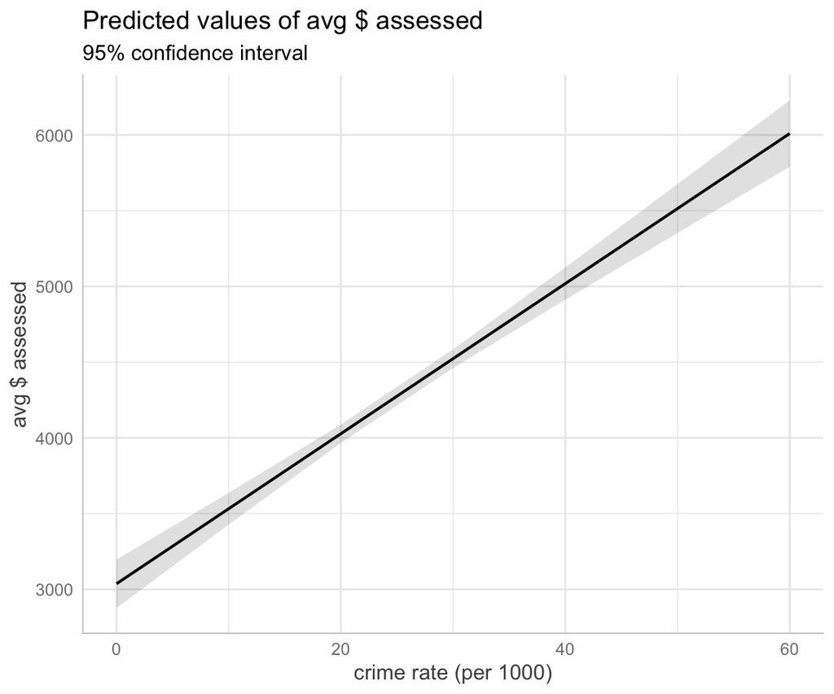

```r
ggpredict(model1, terms = "crt", interval = "confidence", ci.level = .95) %>%
  plot() +
  labs(subtitle = "95% confidence interval")
```

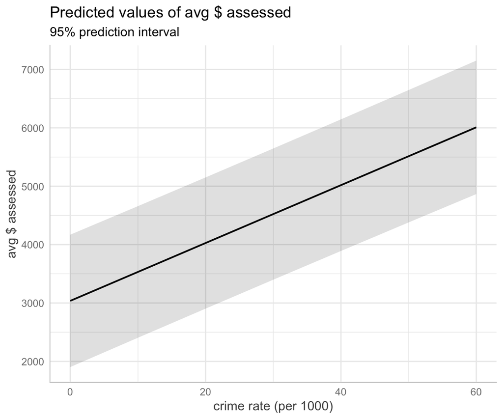

```r
ggpredict(model1, terms = "crt", interval = "prediction", ci.lvl = .95) %>%
  plot() +
  labs(subtitle = "95% prediction interval")
```

# Interaction terms

That’s a simple association. Let’s a second model, adding an interaction term:

```r
f2 <- update(f1, ~ . + crt*minority)
model2 <- glm(f2, family = gaussian(), data = courtpenalties)
tidy(model2)
```

```
## # A tibble: 7 x 5
##   term         estimate std.error statistic  p.value
##   <chr>           <dbl>     <dbl>     <dbl>    <dbl>
## 1 (Intercept)  224.     241.          0.929 3.53e- 1
## 2 minority       0.678    0.121       5.61  3.66e- 8
## 3 liberal        2.14     4.38        0.489 6.25e- 1
## 4 popsize        0.0837   0.00507    16.5   6.60e-48
## 5 crt            7.36     5.14        1.43  1.53e- 1
## 6 unemp          4.49     5.38        0.834 4.05e- 1
## 7 minority:crt   0.0434   0.00443     9.79  1.32e-20
```

Now the association between `crt` and `penalties` depends on the size of the non-white population. Let’s pick 3 values of `minority` for our plot.

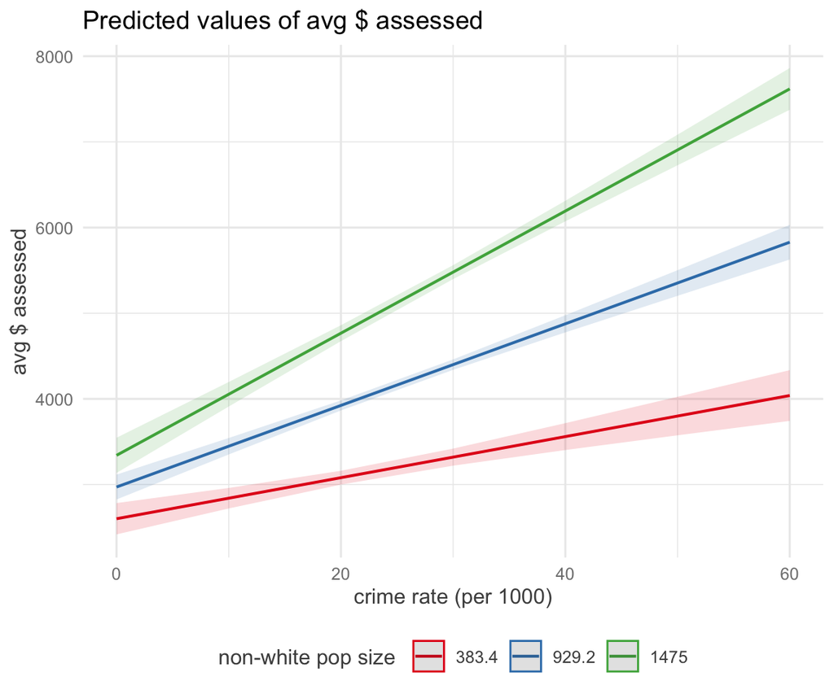

```r
model2_predictions <- ggpredict(model2, terms = c("crt", "minority [meansd]"))

plot(model2_predictions) + theme(legend.position = "bottom")
```

Again, with prediction intervals instead:

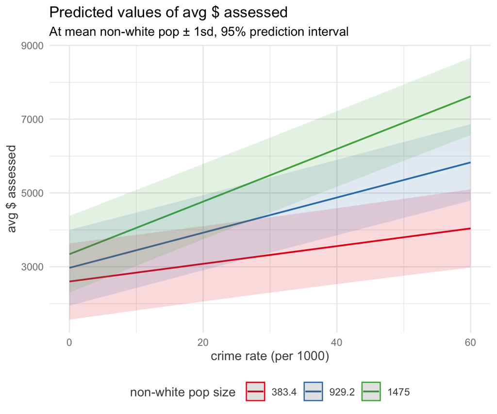

```r
ggpredict(model2,
          terms = c("crt", "minority [meansd]"),
          interval = "prediction") %>%
  plot() +
  labs(subtitle = "At mean non-white pop ± 1sd, 95% prediction interval") +
  theme(legend.position = "bottom")
```

Still want tables?

```r
library(texreg) # or stargazer, or pander ...
htmlreg(list(model1, model2), doctype = FALSE)
```

Statistical models

|  | **Model 1** | **Model 2** |  |
| --- | --- | --- | --- |
| (Intercept) | -985.43*** | 223.67 |  |
|  | (227.96) | (240.74) |  |
| minority | 1.72*** | 0.68*** |  |
|  | (0.06) | (0.12) |  |
| liberal | 2.76 | 2.14 |  |
|  | (4.84) | (4.38) |  |
| popsize | 0.09*** | 0.08*** |  |
|  | (0.01) | (0.01) |  |
| crt | 49.54*** | 7.36 |  |
|  | (3.09) | (5.14) |  |
| unemp | 15.68** | 4.49 |  |
|  | (5.80) | (5.38) |  |
| minority:crt |  | 0.04*** |  |
|  |  | (0.00) |  |
| AIC | 6906.76 | 6820.67 |  |
| BIC | 6935.43 | 6853.43 |  |
| Log Likelihood | -3446.38 | -3402.33 |  |
| Deviance | 143547747.68 | 117714252.43 |  |
| Num. obs. | 444 | 444 |  |
| p < 0.001, p < 0.01, p < 0.05 |  |  |  |

# Logistic regression

```r
grants <- read_csv("data/fedgrants&researchclimate.csv")
```

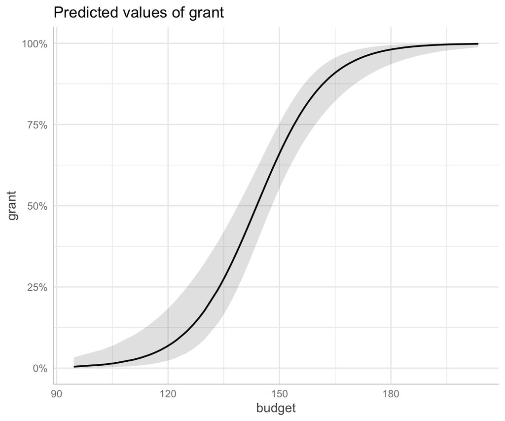

```r
grants <-
  grants %>%
  mutate(grant = ifelse(fedgrants > 0, 1, 0))

model3 <- glm(grant ~ hidegree + budget + climate,
              family = binomial(link = "logit"),
              data = grants)

ggpredict(model3, terms = "budget [all]", interval = "confidence") %>% plot()
```

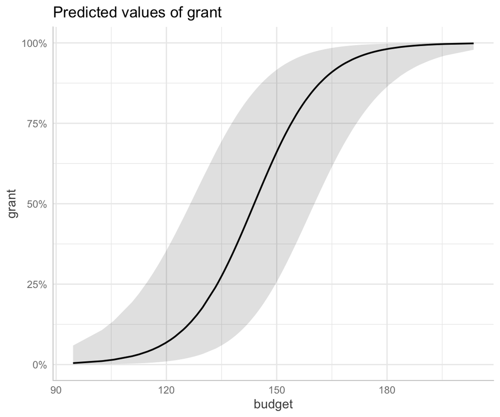

```r
ggpredict(model3, terms = "budget [all]", interval = "prediction") %>% plot()
```

# Resources

http://socviz.co/modeling.html

https://clanfear.github.io/CSSS508/Lectures/Week10/CSSS508_Week10_reproducibility_and_model_results.html

https://strengejacke.github.io/ggeffects/